# Neonatal Deaths - The Silent Crisis 🩺

Analysis based on UNICEF Data

Author

Anushree Srinivasan - 15139

## **Introduction**

Despite record progress in global healthcare, where a child is born remains one of the most decisive factors in their chances of survival. While neonatal mortality rates (NMR) have fallen over the decades, the pace and extent of improvement vary greatly by region, economy, and access to care. This article presents trends, causes, and inequalities in neonatal mortality — and what this reveals about health equity worldwide.

**1. A Global Map of Neonatal Risk**

This map gives a stark picture of health inequities across the globe by highlighting the average neonatal mortality rates from **2013 to 2022**. Countries colored dark red, majorly in African Continent, with a few being in Asia have the highest newborn mortality rates, reflecting compromised healthcare systems and an **urgent need for intervention**. Lighter regions like Europe, North America, and parts of Oceania are countries with well-maintained healthcare infrastructure and low have NMRs. What is most remarkable is not just the progress made, but the sheer disparity between the nations.

This shows the hard reality - **A child’s chances of survival still remain largely conditioned on the location of their birth.**

```python
import polars as pl
from plotnine import *
import geopandas as gp
import pandas as pd

gapminder = pl.read_csv(
    "data_set.csv",
    schema_overrides={"Population_total": pl.Float64}
)
```

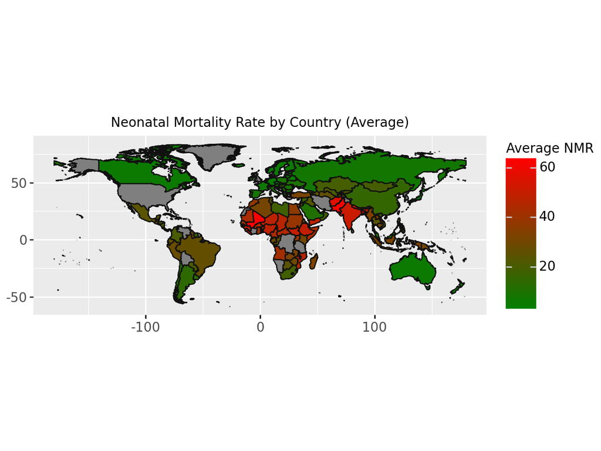

```python
average_NMR = (gapminder
    .group_by("country")
    .agg(pl.col("NMR_Value").mean().alias("avg_NMR"))
)

shape_world = gp.read_file("https://public.opendatasoft.com/api/explore/v2.1/catalog/datasets/world-administrative-boundaries/exports/shp")

map_NMR = (shape_world
    .merge(average_NMR.to_pandas(), left_on="name", right_on="country", how="outer")
)

(ggplot(data=map_NMR)
    + aes(fill="avg_NMR")
    + geom_map()
    + coord_fixed()
    + scale_fill_gradient(low="green", high="red")
    + theme(text=element_text(size=10, family="Times New Roman"))
    + labs(title="Neonatal Mortality Rate by Country (Average)",
           fill="Average NMR")
)
```

**2. Neonatal Mortality in the Last Decade (2013–2022)**

While the global trend is towards improvement, these figures point to persisting inequalities: **Where a child is born still has a significant impact on their chances of surviving the first month of life.**

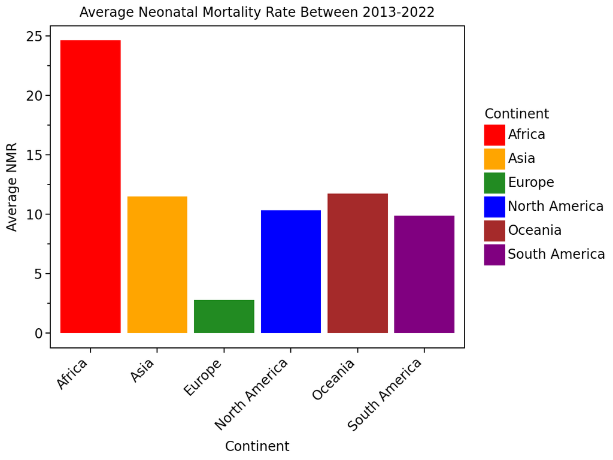

```python
gapminder_last_10_years = gapminder.filter(pl.col("year").is_between(2013, 2022))

gapminder_avg_continent_last_10 = (
  gapminder_last_10_years
  .group_by(pl.col("Continent"))
  .agg(
    pl.col("NMR_Value").mean().alias("avg_NMR")
  )
)

color_map = {
    'Africa': 'red',
    'Asia': 'orange',
    'Europe': 'forestgreen',
    'North America': 'blue',
    'South America': 'purple',
    'Oceania': 'brown'
}

(ggplot(data=gapminder_avg_continent_last_10)
  + aes(x="Continent", y="avg_NMR", fill="Continent")
  + geom_col()
  + scale_fill_manual(values=color_map)
  + theme_matplotlib()
  + theme(text=element_text(size=10, family="Times New Roman"),
          axis_text_x=element_text(rotation=45, hjust=1))
  + labs(title="Average Neonatal Mortality Rate Between 2013-2022", y="Average NMR", x="Continent")
)
```

**3. Long March of Progress**

Looking at history, the global fight against neonatal mortality has not been an easy or short one.

What is heartening is that all continents have seen dramatic reductions in neonatal mortality over the decades, showing global resilience of innovation, vaccines, healthcare access, and education.

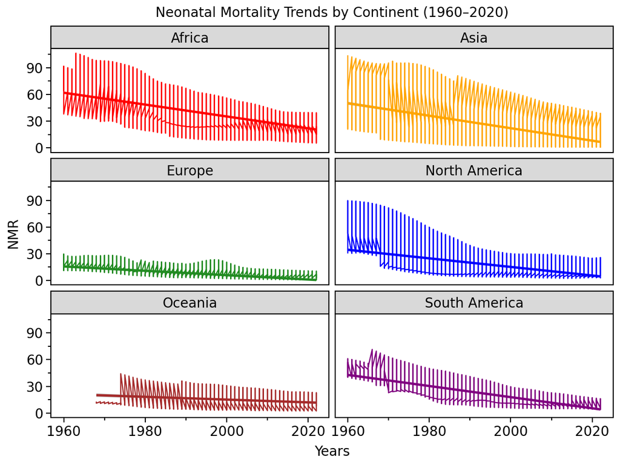

```python
(
    ggplot(gapminder)
    + aes(x='year', y='NMR_Value', color='Continent')
    + geom_line()
    + geom_smooth(method='lm')
    + facet_wrap('~Continent', nrow=3)
    + scale_color_manual(values={
        'Africa': 'red',
        'Asia': 'orange',
        'Europe': 'forestgreen',
        'North America': 'blue',
        'South America': 'purple',
        'Oceania': 'brown'
    })
    + labs(
        x='Years',
        y='NMR',
        title='Neonatal Mortality Trends by Continent (1960–2020)'
    )
    + theme_matplotlib ()
    + theme(text=element_text(size=10, family="Times New Roman"))
    + guides(color=False)
)
```

**4. Health, Wealth and Survival - A Recent Snapshot (2022)**

Zooming in to 2022, the world shows a clear — if uneven — picture of the relationship between neonatal survival, health, and wealth.

In 2022, wealthier countries live longer and healthier lives, but **economic growth must be supplemented with investments in health to actually reduce neonatal mortality and raise life expectancy.**

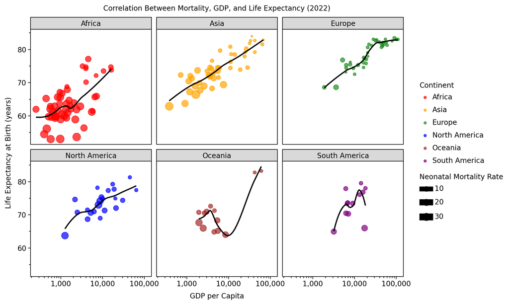

```python
gapminder_2022 = (
    gapminder
    .filter(pl.col("year") == 2022)
    .select([
        pl.col("country"),
        pl.col("Continent"),
        pl.col("GDP"),
        pl.col("Life expectancy at birth, total (years)"),
        pl.col("NMR_Value")
    ])
    .drop_nulls()
    .to_pandas()
)

(
    ggplot(gapminder_2022)
    + aes(
        x='GDP',
        y='Life expectancy at birth, total (years)',
        size='NMR_Value',
        color='Continent'
    )
    + geom_point(alpha=0.7)
    + scale_x_log10()
    + geom_smooth(method='loess', se=False, color='black')
    + facet_wrap('~Continent')
     + scale_color_manual(values={
        'Africa': 'red',
        'Asia': 'orange',
        'Europe': 'forestgreen',
        'North America': 'blue',
        'South America': 'purple',
        'Oceania': 'brown'
    })
    + scale_x_log10(labels=lambda l: [f'{int(v):,}' for v in l])
    + theme_matplotlib()
      + theme(text=element_text(size=10, family="Times New Roman"))
    + labs(
        title="Correlation Between Mortality, GDP, and Life Expectancy (2022)",
        x="GDP per Capita",
        y="Life Expectancy at Birth (years)",
        size="Neonatal Mortality Rate"
    )
    + theme(figure_size=(10, 6))
)
```

**5. More Births equals More Losses?**

- The trendline confirms that as neonatal mortality declines, birth rates also decline but this effect tapers off at very high NMR. Larger countries, particularly in Asia, contribute significantly to world birth rates even where neonatal prospects have improved.
- This highlights a key link - Investments in health not only reduce infant deaths but also support lower fertility and long-term social and economic progress.
- Rapid population growth in the past often kept ahead of medical care, even in more prosperous nations. Countries that managed to stabilise population growth over decades were able to advance health gains and sustain healthcare investment.

*Higher neonatal mortality is closely tied to higher birth rates and population growth. Investing in healthcare not only saves newborn lives but also drives long-term population and economic shifts.*

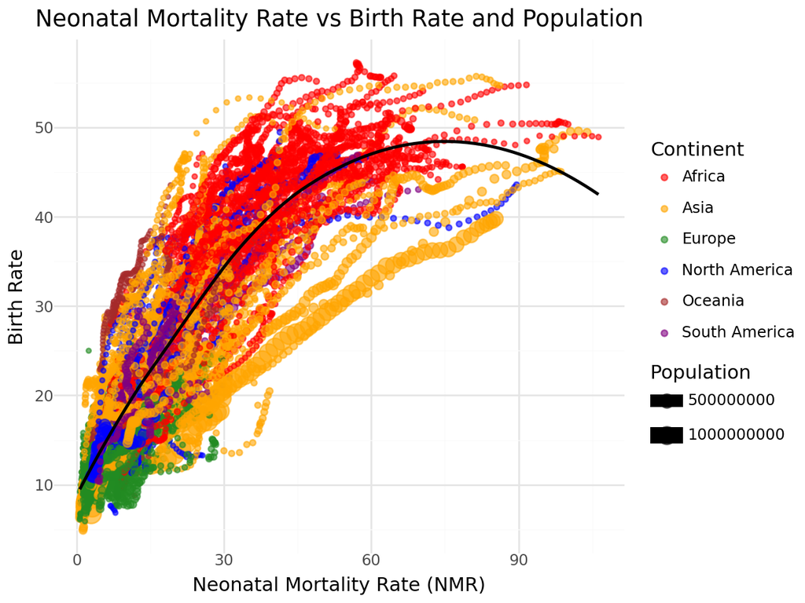

```python
(
 ggplot(gapminder)
 + aes(x="NMR_Value", y="Birth_rate", size="Population_total", color="Continent")
 + geom_point(alpha=0.6)
 + geom_smooth(method="loess", se=False, color="black")
  + scale_color_manual(values={
        'Africa': 'red',
        'Asia': 'orange',
        'Europe': 'forestgreen',
        'North America': 'blue',
        'South America': 'purple',
        'Oceania': 'brown'
    })
 + theme_minimal()
 + labs(
     title="Neonatal Mortality Rate vs Birth Rate and Population",
     x="Neonatal Mortality Rate (NMR)",
     y="Birth Rate",
     size="Population",
     color="Continent"
   )
)
```

**6. Neonatal Mortality: Leaders vs. Lagging Countries**

If we look at neonatal mortality over several years, we are seeing patterns above GDP and life expectancy — a testament to the profound influence of hospital beds, birth rates, and population growth.

To bridge the gap between top performers and struggling nations, international support and resources are essential. **Strengthening healthcare infrastructure and improving maternal care can save countless newborn lives. Global collaboration is key to reducing neonatal mortality worldwide.**

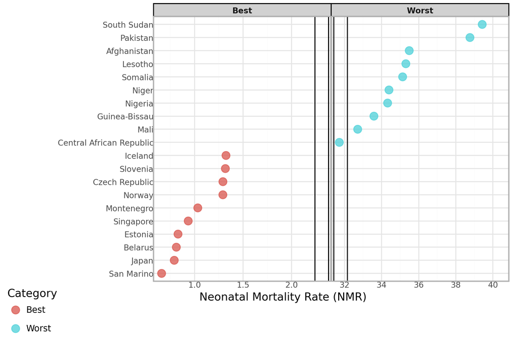

```python
import patchworklib as pw
import polars as pl
from plotnine import *
import pandas as pd

gapminder_2022 = gapminder.filter(pl.col("year") == 2022)

top10_best = gapminder_2022.sort("NMR_Value").head(10).to_pandas()
top10_worst = gapminder_2022.sort("NMR_Value", descending=True).head(10).to_pandas()

top10_best["Category"] = "Best"
top10_worst["Category"] = "Worst"
combined_df = pd.concat([top10_best, top10_worst])

#
plot = (
    ggplot(combined_df, aes(x="NMR_Value", y="reorder(country, NMR_Value)", color="Category"))
    + geom_point(size=4, alpha=0.8)
    + geom_text(
        aes(label="None"),
        nudge_x=1,
        size=8,
        ha='left',
        va='center',
        show_legend=False
    )
    + facet_wrap("~Category", scales="free_x", nrow=1)
    + theme_minimal()
    + theme(
        axis_title_y=element_blank(),
        axis_text_y=element_text(size=8),
        axis_text_x=element_text(size=8),
        strip_background=element_rect(fill="#d1d1d1"),
        strip_text=element_text(size=8, weight='bold'),
        panel_spacing=0.8,
        plot_margin={"t": 0.3, "r": 0.3, "b": 0.2, "l": 0.2},
        legend_position='none',
        text=element_text(family="Times New Roman")
    )
    + labs(
        x="Neonatal Mortality Rate (NMR)"
    )
)

pw.load_ggplot(plot)
```

## **Conclusion**

Neonatal mortality is a significant issue across the globe with glaring inconsistencies between nations. With better wealth and health care, there remain nations with unimproved healthcare infrastructure with high NMRs.The relationship between birth facilities, births, and population growth is critical in the calculation of neonatal survival rates. **Bridging these gaps requires international solidarity, ongoing investment in healthcare, and policy to prioritize maternal and neonatal health so that all newborns have an equal chance for survival regardless of where he or she was born.**

*Make a difference today,[TAKE ACTION](https://www.unicef.org/take-action)*

*Data sourced from [UNICEF](https://data.unicef.org/dv_index/) & [World Bank Data](https://databank.worldbank.org/source/world-development-indicators)*